# Predicting Box Office Revenue of Movies Released During the COVID-19 Pandemic Lockdowns

Julianna Harwood

February 2022

## Introduction

The purpose of this project is to use common machine learning algorithms to predict the box office performance of movies that could not be released in theaters because of the lock downs associated with COVID-19.

- imdb_id (string): Unique identifier of the movie
- title_name (string): Title of movie
- totalbox (int): Total box office revenue of movie ($)
- mpaarating (string): MPA rating of movie
- grade (string): CinemaScore movie grade
- genre (string): Movie genre
- title_launch_date (string): Date of movie opening
- rotten_tomatoes_score (float): Rotten Tomatoes score
- Interest_index (float): Metric to measure interest in movie (unknown source)
- wiki_pre_wk1_pageviews: Total views of the movie’s Wikipedia page prior to release

## Analysis

### Inspect and Clean Data

Read in and summarize data to check for missing data and understand what cleaning needs to be done.

```r
df <- read_excel('box_pred_sample_test_data.xlsx')
summary(df)
```

```
##    imdb_id           title_name           totalbox          mpaarating
##  Length:1065        Length:1065        Min.   :  1030502   Length:1065
##  Class :character   Class :character   1st Qu.: 16580391   Class :character
##  Mode  :character   Mode  :character   Median : 39690146   Mode  :character
##                                        Mean   : 75151563
##                                        3rd Qu.: 85482890
##                                        Max.   :858373000
##                                        NA's   :29
##     grade           title_launch_date                   genre
##  Length:1065        Min.   :2016-01-04 00:00:00.00   Length:1065
##  Class :character   1st Qu.:2017-04-21 00:00:00.00   Class :character
##  Mode  :character   Median :2018-03-23 00:00:00.00   Mode  :character
##                     Mean   :2018-04-11 22:56:27.03
##                     3rd Qu.:2019-03-08 00:00:00.00
##                     Max.   :2021-07-27 00:00:00.00
##
##  rotten_tomatoes_score wiki_pre_wk1_pageviews Interest_index
##  Min.   :11.00         Min.   :     15.0      Min.   :     99.6
##  1st Qu.:48.25         1st Qu.:    954.8      1st Qu.:   7816.5
##  Median :67.00         Median :  14802.5      Median :  16955.1
##  Mean   :64.80         Mean   :  47738.3      Mean   :  43284.4
##  3rd Qu.:82.00         3rd Qu.:  57277.2      3rd Qu.:  43334.4
##  Max.   :99.00         Max.   :1156621.0      Max.   :1285447.3
##  NA's   :55            NA's   :585
```

```r
sum(is.na(df$grade))
```

```
## [1] 302
```

```r
sum(!is.na(df$grade[is.na(df$totalbox)]))
```

```
## [1] 1
```

```r
sum(!is.na(df$wiki_pre_wk1_pageviews[is.na(df$totalbox)]))
```

```
## [1] 2
```

Convert categorical data to factors and define *title_launch_date* as a date.

```r
df$mpaarating <- as.factor(df$mpaarating)
df$grade <- as.factor(df$grade)
df$genre <- as.factor(df$genre)
df$title_launch_date <- as.Date(df$title_launch_date)
```

To gain more insight from the *title_launch_day* variable, I create variables for release month, day and weekday.

```r
# create month, day and weekday variables
df$release_month <- as.numeric(format(df$title_launch_date, "%m"))
months_nums = c(1,2,3,4,5,6,7,8,9,10,11,12)
months_names = c("Jan","Feb","Mar","Apr","May","Jun","Jul","Aug","Sep","Oct","Nov","Dec")
df$release_month <- factor(df$release_month, levels = months_nums, labels = months_names)

df$release_day <- as.numeric(format(df$title_launch_date, "%d"))
df$release_weekday <- as.factor(weekdays(df$title_launch_date))
```

Lastly, I save the *imdb_id* and *title_name* of the post covid movies to be used later.

```r
post_covid_ids <- df[is.na(df$totalbox),c("imdb_id","title_name")]
```

### Bivariate Analysis

To understand relationships between the data, I perform bivariate analysis on the average *totalbox* for different levels of the factor variables.

```r
aggregate(totalbox ~ grade, df, mean)
```

```
##    grade  totalbox
## 1      A 165827890
## 2     A- 108296423
## 3     A+ 258190255
## 4      B  48437563
## 5     B-  33604006
## 6     B+  69597878
## 7      C  26181532
## 8     C-  14818747
## 9     C+  21877571
## 10     D   8747046
## 11    D-   5775178
## 12    D+  28978276
## 13     F  17800004
```

```r
aggregate(totalbox ~ mpaarating, df, mean)
```

```
##   mpaarating  totalbox
## 1          G 152127946
## 2         PG 102164731
## 3      PG-13  88328969
## 4          R  45862474
```

```r
aggregate(totalbox ~ genre, df, mean)
```

```
##               genre  totalbox
## 1            Action 136013046
## 2  Action/Adventure  37016922
## 3         Adventure 243550282
## 4         Animation 130668101
## 5            Comedy  41295570
## 6       Documentary  12107972
## 7             Drama  39022035
## 8            Family 150189616
## 9            Horror  57271931
## 10          Musical 118310920
## 11 Mystery Suspense  38545388
## 12  Science Fiction  44627815
```

```r
aggregate(totalbox ~ release_month, df, mean)
```

```
##    release_month  totalbox
## 1            Jan  45212807
## 2            Feb  69263279
## 3            Mar  74411715
## 4            Apr  87271966
## 5            May  87725040
## 6            Jun 102479894
## 7            Jul  99466485
## 8            Aug  51265446
## 9            Sep  51580897
## 10           Oct  41188223
## 11           Nov  91764210
## 12           Dec  99143778
```

```r
aggregate(totalbox ~ release_weekday, df, mean)
```

```
##   release_weekday  totalbox
## 1          Friday  72931040
## 2          Monday  76324389
## 3          Sunday  80103209
## 4        Thursday 134189012
## 5         Tuesday  87672007
## 6       Wednesday  95589394
```

### Train Models

As a baseline, I will use simple linear regression to predict *totalbox*. The lm package of R does not have a robust way of fitting data with missing values, so I leave *grade*, *rotten_tomatoes_score* and *wiki_pre_wk1_pageviews* out. I choose an 80/20 split of the final dataset to fit and test the model. The primary success metric I will use is Root Mean Squared Error (RMSE), which measures the amount, on average, the predictions deviate from the observed data. Another success metric I will look at is R-Squared, which measures the amount of variance in the response variable explained by the predictors. When tested on the test dataset, the model has an R-Squared of 0.688, meaning that 68.8% of the variance in *totalbox* can be explained from the model. The RMSE of 5.97e+07 means that on average, this model has an error of about $59.7M.

```r
# create final dataset
df$title_launch_date <- as.numeric(as.POSIXct(df$title_launch_date))
vars <- c("totalbox","mpaarating","genre","Interest_index",
          "release_month","release_day",
          "title_launch_date","release_weekday")
final_df <- df[,vars]

# split post covid titles for prediction with final model
post_covid_titles <- final_df[is.na(final_df$totalbox),]
final_df <- final_df[!is.na(final_df$totalbox),]

# create test and train datasets
set.seed(1234)
index <- createDataPartition(final_df$totalbox, p=.8, list=FALSE)
train <- final_df[index,]
test <- final_df[-index,]

# fit linear regression model
set.seed(1234)
fit <- lm(totalbox ~ . - release_weekday, data = train, na.action = na.omit)
fit
```

```
##
## Call:
## lm(formula = totalbox ~ . - release_weekday, data = train, na.action = na.omit)
##
## Coefficients:
##           (Intercept)           mpaaratingPG        mpaaratingPG-13
##             5.169e+08             -1.738e+07             -1.848e+07
##           mpaaratingR  genreAction/Adventure         genreAdventure
##            -4.288e+07             -5.312e+07             -2.920e+06
##        genreAnimation            genreComedy       genreDocumentary
##             5.518e+06             -4.115e+07             -6.686e+07
##            genreDrama            genreFamily            genreHorror
##            -5.090e+07              2.506e+07             -3.460e+07
##          genreMusical  genreMystery Suspense   genreScience Fiction
##            -9.741e+07             -3.925e+07             -4.360e+07
##        Interest_index       release_monthFeb       release_monthMar
##             8.275e+02              4.365e+06              1.057e+07
##      release_monthApr       release_monthMay       release_monthJun
##            -1.027e+07              1.403e+07              3.662e+07
##      release_monthJul       release_monthAug       release_monthSep
##             3.104e+07             -1.091e+05              5.515e+06
##      release_monthOct       release_monthNov       release_monthDec
##             4.701e+06              3.879e+07              3.457e+07
##           release_day      title_launch_date
##            -3.405e+05             -2.830e-01
```

```r
pred_lm <- predict(fit, test)
postResample(pred=pred_lm, obs=test$totalbox)
```

```
##         RMSE     Rsquared          MAE
## 5.974061e+07 6.879007e-01 3.755570e+07
```

To improve on these predictions, I use a Random Forest model. Random Forest models do not have the same assumptions as linear regression models with regards to normality of the predictor variables. They works well “out of the box” for many different types of data. It also has an option to impute missing data while training, so I am able to add in *grade*, *rotten_tomatoes_score* and *wiki_pre_wk1_pageviews* as predictors. I again use an 80/20 split for training and testing data and grow 400 trees.

```r
# create final dataset
vars <- c("totalbox","mpaarating","genre","Interest_index",
          "release_month","release_day", "grade", "wiki_pre_wk1_pageviews",
          "rotten_tomatoes_score","title_launch_date","release_weekday")
final_df <- df[,vars]

# split post covid titles for prediction with final model
post_covid_titles <- final_df[is.na(final_df$totalbox),]
final_df <- final_df[!is.na(final_df$totalbox),]

# create test and train datasets
set.seed(1234)
index <- createDataPartition(final_df$totalbox, p=.8, list=FALSE)
train <- final_df[index,]
test <- final_df[-index,]

# fit initial model
set.seed(1234)
fit.forest.initial <- randomForest(totalbox ~ ., data = train,
                             ntree = 400, na.action = na.roughfix, importance = TRUE)
pred.initial <- predict(fit.forest.initial, test)
postResample(pred=pred.initial, obs=test$totalbox)
```

```
##         RMSE     Rsquared          MAE
## 4.271007e+07 9.381894e-01 2.462965e+07
```

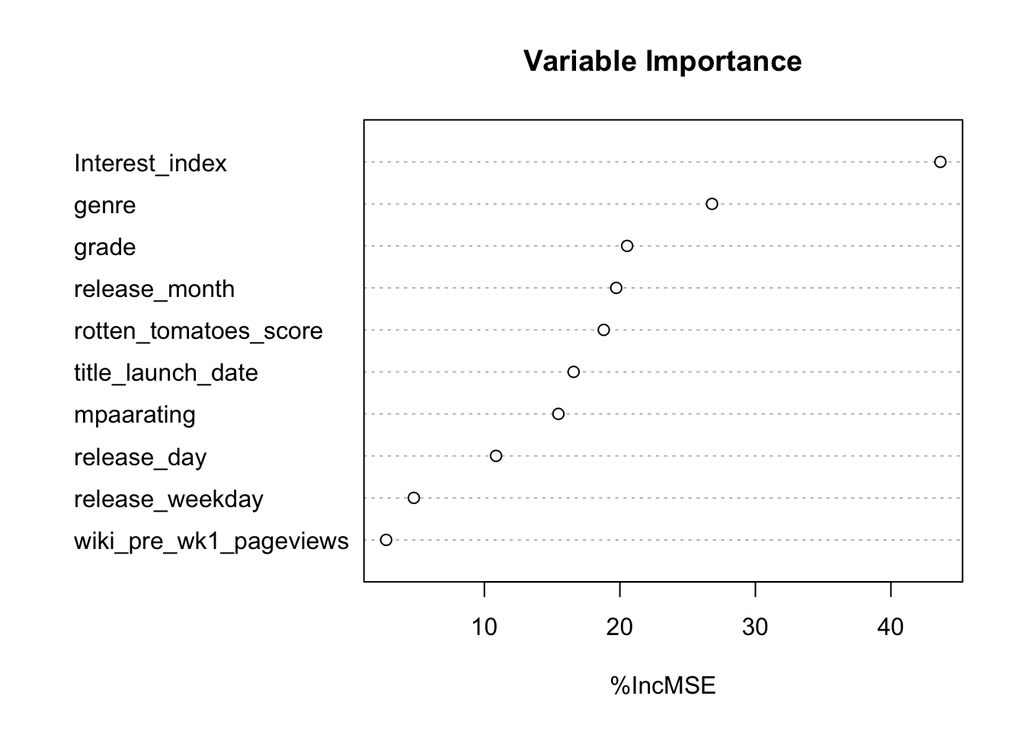

```r
varImpPlot(fit.forest.initial, type = 1, main = "Variable Importance")
```

The RMSE and Rsquared have improved drastically with the RandomForest. From the Variable Importance plot, *Interest_index* is by far the most important variable. The %IncMSE on the X-axis measures the percent change in the mean squared error of the predictions if that variable had been left out of the model. *wiki_pre_wk1_pageviews* is the least important variable and given that about 50% of it is missing values, I try the model without it, and get a slight decrease in RMSE.

```r
# fit model without wiki_pre_wk1_pageviews
set.seed(1234)
fit.forest.initial <- randomForest(totalbox ~ . - wiki_pre_wk1_pageviews, data = train,
                             ntree = 400, na.action = na.roughfix, importance = TRUE)
pred.initial <- predict(fit.forest.initial, test)
postResample(pred=pred.initial, obs=test$totalbox)
```

```
##         RMSE     Rsquared          MAE
## 3.756606e+07 9.470529e-01 2.157047e+07
```

Next, I try a manual grid search across possible hyperparameters mtry and ntree. mtry is the number of variables sampled as candidates at each split and ntree is the number of trees grown for each forest model. I store all results and save the best model.

```r
final_df = subset(final_df, select = - c(wiki_pre_wk1_pageviews))
post_covid_titles <- subset(post_covid_titles, select = - wiki_pre_wk1_pageviews)

# create test and train datasets
set.seed(1234)
index <- createDataPartition(final_df$totalbox, p=.8, list=FALSE)
train <- final_df[index,]
test <- final_df[-index,]

# tune random fo
mtrys = c(3,4,5,6,7,8,9)
ntrees = c(100, 300, 500,700,900,1100)

tune_results <- data.frame(matrix(ncol = length(ntrees), nrow = length(mtrys)))
colnames(tune_results) <- ntrees
rownames(tune_results) <- mtrys

lowest_RMSE <- 100000000

for (mtry in mtrys)
{
  for (ntree in ntrees)
       {
         set.seed(1234)
         fit.forest <- randomForest(totalbox ~ ., data = train,
                             ntree = ntree, mtry = mtry, na.action = na.roughfix, importance = TRUE)
         pred <- predict(fit.forest, test)
         results <- postResample(pred=pred, obs=test$totalbox)
         tune_results[toString(mtry),toString(ntree)] <- results[["RMSE"]]
         if (results[["RMSE"]] < lowest_RMSE) {
           lowest_RMSE <- results[["RMSE"]]
           final_results <- results
           final_model <- fit.forest
         }
       }
}

tune_results
```

```
##        100      300      500      700      900     1100
## 3 35894565 34169129 34018740 34185284 33957536 33792225
## 4 33015046 33355303 33088259 32801509 32417405 32377249
## 5 32467938 31540687 31930467 31997982 32555026 32500386
## 6 30632322 32552173 32285515 32038570 32063866 32164527
## 7 31012067 31258641 31807479 32083529 32509136 32151022
## 8 30974131 33038429 32565002 32659774 32745974 32704674
## 9 32838895 33238358 33141291 33194820 33085773 32953689
```

```r
final_results
```

```
##         RMSE     Rsquared          MAE
## 3.063232e+07 9.414750e-01 1.888714e+07
```

As another tuning method, I use the caret package to autotune the RandomForest. I use repeated cross-validation with 10 different values of mtry and 500 trees. As caret does not have the na.roughfix option that the RandomForest package has, I use k nearest neighbors to impute the missing *rotten_tomatoes_score* and *grade* values.

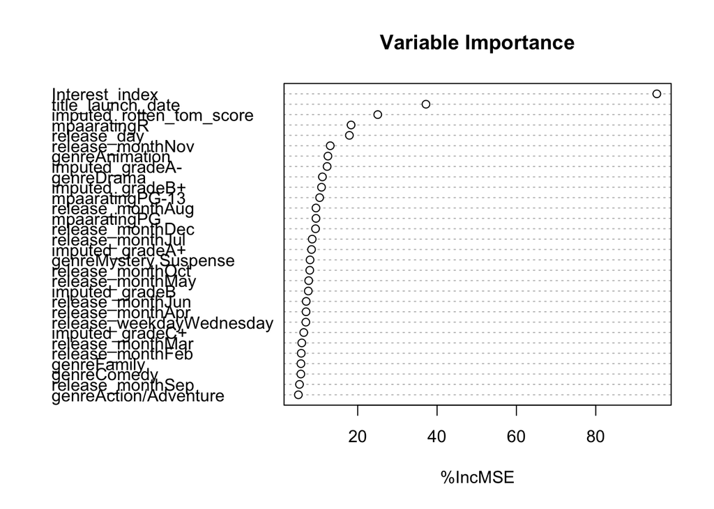

```r
# create final dataset
final_df <- df[,vars]

# impute missing values
imputed_data <- knnImputation(final_df, scale = TRUE)
final_df <- cbind(final_df, imputed_data$rotten_tomatoes_score, imputed_data$grade)
final_df <- rename(final_df, 'imputed_rotten_tom_score' = 'imputed_data$rotten_tomatoes_score')
final_df <- rename(final_df, 'imputed_grade' = 'imputed_data$grade')
final_df = subset(final_df, select = - c(rotten_tomatoes_score,grade,wiki_pre_wk1_pageviews))

# split post covid titles for prediction with final model
post_covid_titles <- final_df[is.na(final_df$totalbox),]
final_df <- final_df[!is.na(final_df$totalbox),]

# create test and train datasets
set.seed(1234)
index <- createDataPartition(final_df$totalbox, p=.8, list=FALSE)
train <- final_df[index,]
test <- final_df[-index,]

# train and tune model with train data
control <- trainControl(method="repeatedcv", number=10, repeats=3, search="grid")
set.seed(1234)
final.forest <- train(totalbox ~ ., data = train,
                      trControl = control,
                      preProcess = c("center","scale"),
                      tuneLength = 10, ntree = 500, metric = "RMSE", method = "rf", importance = TRUE)


# plot variable importance
varImpPlot(final.forest$finalModel, type = 1, main = "Variable Importance")
```

```r
# test on test dataset
tuned_pred <- predict(final.forest, test)
results_caret <- postResample(pred=tuned_pred, obs=test$totalbox)
results_caret
```

```
##         RMSE     Rsquared          MAE
## 2.911173e+07 9.264107e-01 1.717112e+07
```

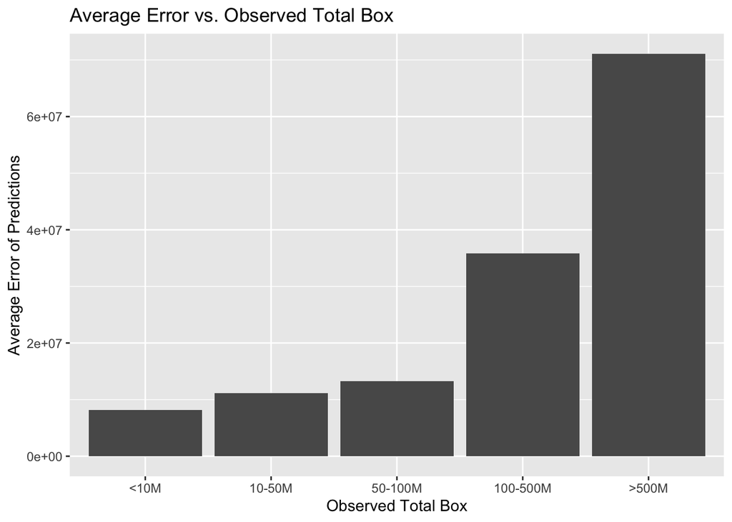

```r
if (results_caret[["RMSE"]] < lowest_RMSE) {
  final_model <- final.forest
}

test$final_pred <- predict(final_model, test)
test$error <- sqrt((test$final_pred - test$totalbox)^2)
final_results <- postResample(pred=test$final_pred, obs=test$totalbox)

test <- test %>% mutate(binned_totalbox =
                     case_when(totalbox <= 10000000 ~ 10,
                               10000000 < totalbox & totalbox <= 50000000 ~ 50,
                               50000000 < totalbox & totalbox <= 100000000 ~ 100,
                               100000000 < totalbox & totalbox <= 500000000 ~ 500,
                               totalbox > 500000000 ~ 900,)
)
test$binned_totalbox <- factor(test$binned_totalbox, levels = c(10,50,100,500,900),
                               labels = c("<10M","10-50M","50-100M","100-500M",">500M"))

ggplot(test, aes(binned_totalbox, error)) +
  geom_bar(stat = "summary",
           fun = "mean") +
  ggtitle("Average Error vs. Observed Total Box") +
  xlab("Observed Total Box") +
  ylab("Average Error of Predictions")
```

Lastly, I use the best model to predict *totalbox* for the post-covid titles.

```r
# make final predictions
post_covid_titles$predicted_totalbox <- predict(final_model, post_covid_titles)
post_covid_titles <- cbind(post_covid_ids,post_covid_titles)
write.csv(post_covid_titles,"predicted_data.csv", row.names = FALSE)
```

## Results

As stated above, I chose RandomForest because it does not depend on the distribution or scale of the predictor variables and is a good “out of the box” model for numerical predictions. I tuned it both with a manual grid search and the automatic tuning that caret provides to choose the best hyperparameters for the final model. I considered dropping more variables from the model and briefly tested other numerical prediction approaches, but saw worse results for RMSE and Rsquared.

The best model was the one tuned by caret and has an R-Squared of 0.9264107, meaning that about 93% of the variance in *totalbox* can be explained from the model. The overall RMSE of 2.9111734^{7} means that on average, this model will have an error of about $29.11M. We can see from the plot of error for different levels of *totalbox* that the error of predictions grows as revenue increases. A possible explanation of this is that because there are more titles that have relatively low revenue, the model is biased towards them and underfit for high revenue titles. Additionally, there are relatively few complete rows and many of the variables are imbalanced, so it’s possible that this model might become much more precise if trained on more data.